# Exploring the BRFSS data

## Setup

### Load packages

```r
library(ggplot2)
library(dplyr)
```

### Load data

```r
load("brfss2013.RData")
```

## Part 1: Data

The primary method of collection of data in this set was through both landline telephone and cellular telelephone-based surveys. With the landline telephone survey, data was collected from a randomly selected adult in a household. In the cellphone-based survey, interviewers collected data from an adult who participated by using a cellphone and resided in a private residence or college housing.

Generalizability - Since the sampled population does not include those individuals who are instititionalized and also does not represent those who do not own a telephone line and cellphone line, there is an issue of a convenience sampling.

Also of importance is the non-response rate for this surveys, the data on the response rate for the 2013 brfss data set can be found here: https://www.cdc.gov/brfss/annual_data/2013/pdf/2013_dqr.pdf

According to the report the median response rate was 46.4% and ranged from 29.0% to 60.3%. The response rate formula used was set by the American Association of Public Opinion Research (AAPOR) Response Rate Formula #4.

Since the average non-response rate is 53.6% and added to the fact the presence of a convenience sample I dont believe it makes much sense to generalize these findings. It may be possible to generalize for certain demographics in the survey if they pass a low enough non-response threshold or if results are also weighted based on the demographic’s specific non-response rate.

Causation - Since the present data is obeservational, we cannot infer any casual associations but can instead only shed light on correlations and associations between variables.

## Part 2: Research questions

**Research quesion 1:**

Considering people that are aged 40yrs to 64 years old - what is the probability that they are in “Excellent” health given that they are retired?

I think most people would like to enter into retirement as soon as they can while still being in good health. I am curious about the health levels of adults who are older than 40 and younger than 65(generally when people are eligible to receive social security) and if their health level and employment status are independent.

**Research quesion 2:**

Is the Frequency Of Days Now Smoking dependent on what month the survey was taken?

The objective of this question is to see if frequency of smoking for surveyed invidivuals was dependent on what month they were surveyed. My initial guess it is independent of when they are surveyed but it is curious if there is an dependency. Is the Frequency lower in say January because of potential New Years Resolutions perhaps?

**Research quesion 3:**

Would the variable for # of children in households be a good indicator of an individuals general health level? Which households by # of children have the highest general health levels?

I am curious about the impact on ones health that having children in your household would have. Would it lowest your health possible? Or would you be generally healthier the larger the atomic family you have?

## Part 3: Exploratory data analysis

**Research quesion 1:**

Considering people that are aged 40yrs to 64 years old - what is the probability that they are in “Excellent” health given that they are retired?

We will be working with three specific variables in the dataset to answer this question: general health level(ordinal categorical), Reported Age in Five-Year Age Categories(ordinal categorical) and Employment Status(categorical).

First we will subset our target data into a new dataframe, we will be selecting the data based on people aged 40 to 64 years old.

```r
#creating new data frame with 40-64 year olds in the dataset
brfss_4064 <- brfss2013[brfss2013$X_ageg5yr %in% c("Age 40 to 44","Age 45 to 49","Age 50 to 54","Age 55 to 59","Age 60 to 64"),]


#changing categorical variables of interest to factors
brfss2013$X_ageg5yr <- as.factor(brfss2013$X_ageg5yr)
brfss2013$employ1 <- as.factor(brfss2013$employ1)
brfss2013$genhlth <- as.factor(brfss2013$genhlth)

brfss_4064$X_ageg5yr <- as.factor(brfss_4064$X_ageg5yr)
brfss_4064$employ1 <- as.factor(brfss_4064$employ1)
brfss_4064$genhlth <- as.factor(brfss_4064$genhlth)
```

++++EMPLOYMENT STATUS

Let us concentrate on one of our potential explanatory variables, employment status.

First we will look at the employment status for the total population with the frequency table(%) below.

```r
#ptable for employment status by % for total population.
ptab_Emplymnt_total <- round(prop.table(table(brfss2013$employ1)),3)
sort(ptab_Emplymnt_total, decreasing=TRUE)
```

```
##
##               Employed for wages                          Retired
##                            0.414                            0.283
##                    Self-employed                   Unable to work
##                            0.082                            0.077
##                      A homemaker   Out of work for 1 year or more
##                            0.065                            0.029
##                        A student Out of work for less than 1 year
##                            0.026                            0.025
```

We can see that 41% are Employed for Wages, 28% Retired, 8% Self-employed, 7% unable to work, 6% homemakers, 3% out of work > 1 yr, 2% students and 2% out of work < 1 yr.

Below we run the frequency table(%) for employment status for those in the 40 - 64 year old range.

```r
#ptable for employment status by % for 40-64 year olds.
ptab_Emplymnt_4064 <- round(prop.table(table(brfss_4064$employ1)),3)
sort(ptab_Emplymnt_4064, decreasing=TRUE)
```

```
##
##               Employed for wages                   Unable to work
##                            0.545                            0.118
##                    Self-employed                          Retired
##                            0.110                            0.100
##                      A homemaker   Out of work for 1 year or more
##                            0.055                            0.039
## Out of work for less than 1 year                        A student
##                            0.028                            0.005
```

We will compute a table below that shows the difference between employment status relative to the general population and the 40-64 yr old subset.

```r
#computes % difference of employment proportion levels of 40-64 yr olds to the total population
sort(ptab_Emplymnt_4064 - ptab_Emplymnt_total, decreasing = TRUE)
```

```
##
##               Employed for wages                   Unable to work
##                            0.131                            0.041
##                    Self-employed   Out of work for 1 year or more
##                            0.028                            0.010
## Out of work for less than 1 year                      A homemaker
##                            0.003                           -0.010
##                        A student                          Retired
##                           -0.021                           -0.183
```

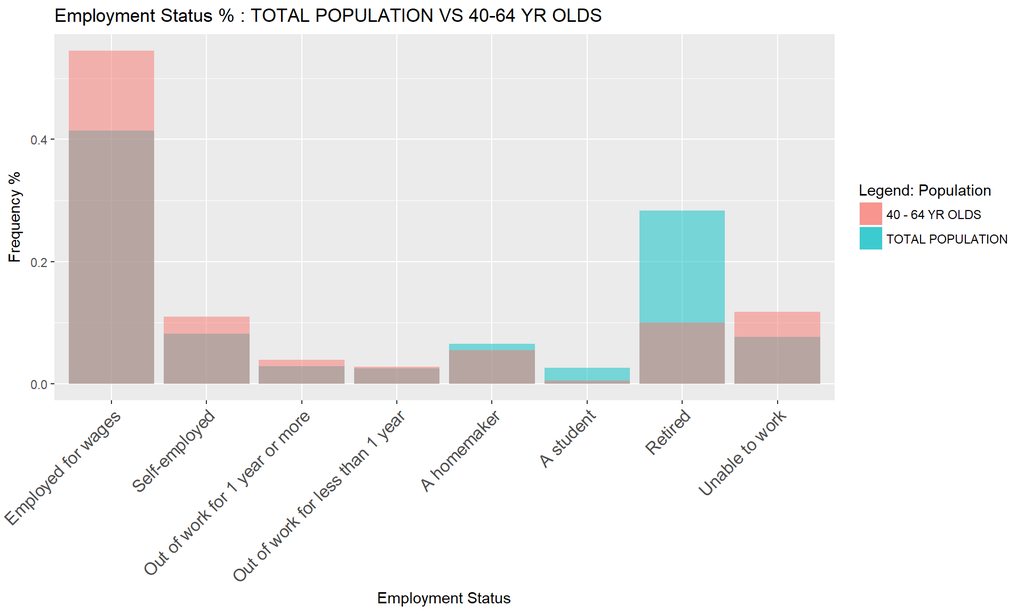

```r
#overlaying barplots for employment status for the total and 40-64 yr old population
ggplot(NULL, aes(employ1)) + geom_bar(aes(y = (..count..)/sum(..count..),fill= "TOTAL POPULATION"), data=subset(brfss2013, !is.na(employ1)), alpha=0.5) + geom_bar(aes(y = (..count..)/sum(..count..),fill= "40 - 64 YR OLDS"), data=subset(brfss_4064, !is.na(employ1)), alpha=0.5) + theme(axis.text.x = element_text(size=12,angle=45,hjust = 1)) + labs(title="Employment Status % : TOTAL POPULATION VS 40-64 YR OLDS", x = "Employment Status", y="Frequency %", fill="Legend: Population")
```

We can see that the biggest differences are in the Employed for Wages and Retired people categories. 13% more of the 40-64 year olds are working for wages compared to the general population and they also have -18% less retired people than the general population. These differences are also illuminated in the compartive bar graphs below.

++++AGE IN FIVE-YEAR AGE CATEGORIES

Now that we have an idea of health level and employment status for the whole data set we will now focus on those aged 40 - 64 years old since that is what our question is concerned with. Lets first take a quick peek at how the total population is been distributed by age group and employment status.

```r
brfss2013$X_ageg5yr <- as.factor(brfss2013$X_ageg5yr)
brfss2013$employ1 <- as.factor(brfss2013$employ1)

#frequency % for a5 yr age groups for total population
sort(round(prop.table(table(brfss2013$X_ageg5yr)),3), decreasing=TRUE)
```

```
##
##    Age 60 to 64    Age 55 to 59    Age 65 to 69    Age 50 to 54
##           0.110           0.108           0.103           0.097
## Age 80 or older    Age 70 to 74    Age 45 to 49    Age 40 to 44
##           0.083           0.082           0.074           0.065
##    Age 75 to 79    Age 35 to 39    Age 18 to 24    Age 30 to 34
##           0.062           0.058           0.056           0.056
##    Age 25 to 29
##           0.047
```

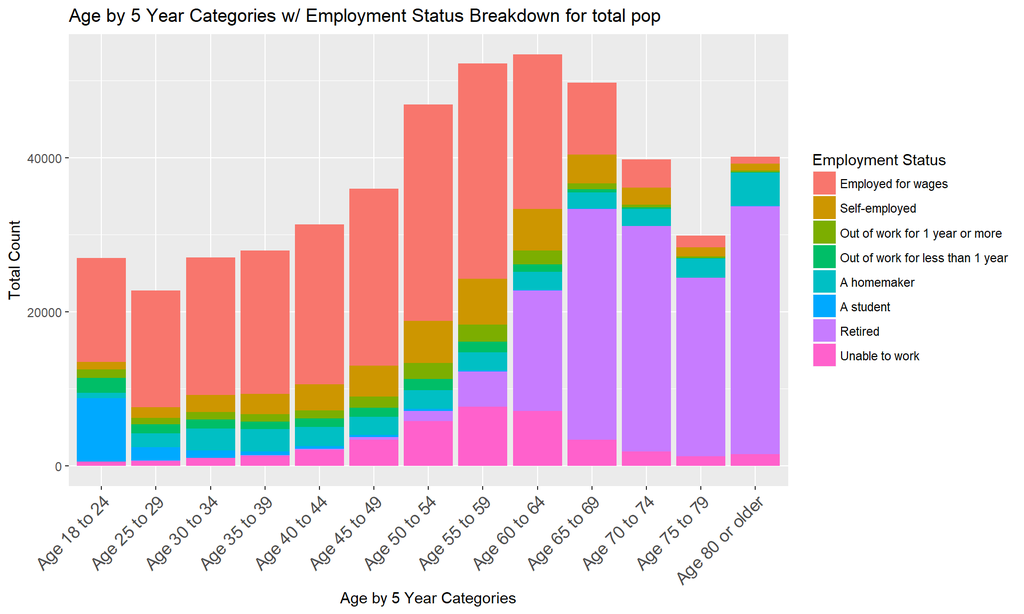

```r
ggplot(data=subset(brfss2013,!is.na(X_ageg5yr) & !is.na(employ1)), aes(x=X_ageg5yr, fill=employ1)) + geom_bar() + theme(axis.text.x = element_text(size=12,angle=45,hjust = 1)) + xlab("Age by 5 Year Categories") + ggtitle("Age by 5 Year Categories w/ Employment Status Breakdown for total pop") + ylab("Total Count") +scale_fill_discrete(name="Employment Status")
```

As we can see we Employed for wages makes up the largest % of the early age groups and then starts siginigcant decreasing at Age 60 - 64 as people become eligible for social security benefits. Likewise the number of retired people starts off as miniscule size in the age 40-44 and eventually dominates by the oldest age group. It is also interesting to note that the largest age group by counts is the Age 60-64 group (11%), this aligns with the notion that the baby boomer generation was one of the largest in American history. We can also start to see the millenials beginning to bulge at the Age 18-24 mark (to be fair their Age category has the longest length at 6 years).

++++GENERAL HEALTH LEVELS

Since the dependent variable we are concerned with is an individual’s general health level, let us see what the probability is for each level of general health for the total population. Also below is a histogram of general health status faceted by employment status for easy comparison between employment status and their level of health.

```r
#probability table for general health levels for entire population
round(prop.table(table(brfss2013$genhlth)),3)
```

```
##
## Excellent Very good      Good      Fair      Poor
##     0.175     0.325     0.307     0.136     0.057
```

```r
#probability table of general health levels of 40-64 year olds
round(prop.table(table(brfss_4064$genhlth)),3)
```

```
##
## Excellent Very good      Good      Fair      Poor
##     0.177     0.328     0.296     0.135     0.063
```

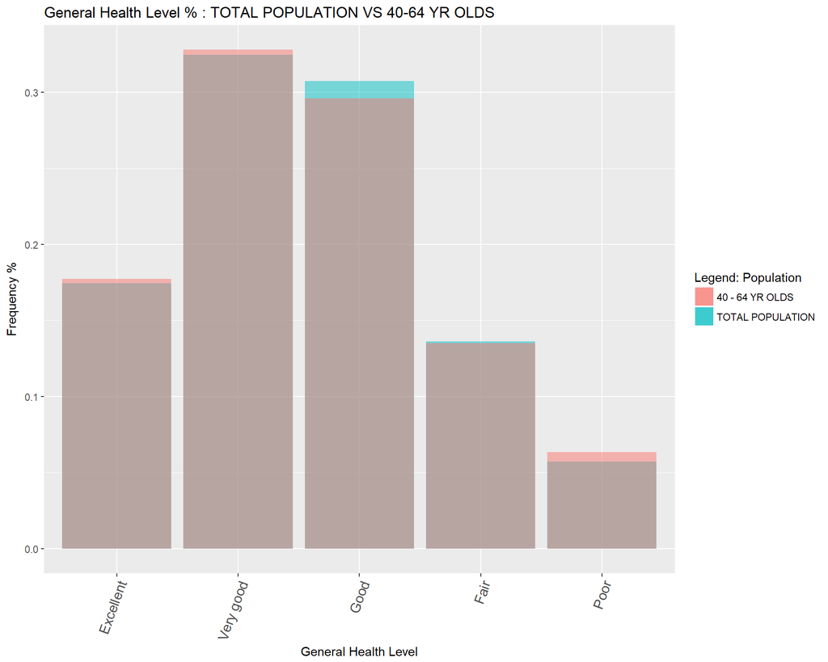

```r
#overlaying comparison barplots for general health level for the total and 40-64 yr old population
ggplot(NULL, aes(genhlth)) + geom_bar(aes(y = (..count..)/sum(..count..),fill= "TOTAL POPULATION"), data=subset(brfss2013, !is.na(genhlth)), alpha=0.5) + geom_bar(aes(y = (..count..)/sum(..count..),fill= "40 - 64 YR OLDS"), data=subset(brfss_4064,!is.na(genhlth)), alpha=0.5) + theme(axis.text.x = element_text(size=12,angle=70,hjust = 1)) + labs(title="General Health Level % : TOTAL POPULATION VS 40-64 YR OLDS", x = "General Health Level", y="Frequency %", fill="Legend: Population")
```

When we compare the general health levels between these two populations we notice that they are pretty similar. This isn’t too surprising since our 40-64 yr old subset was 44% of the total population. The biggest variances are than the total population has a higher chance of being in “Good” health and lower chance of being in “Poor” health when compared directly against the 40-64 yr olds. All the other categories only have slight differences.

+++CONCLUSIONS

Since we’ve finished exploring the our dependent and explanatory variables, lets put it all together. We will be ouputting a relative frequency table and bar graph for the relative frequency for probability of health level given employment status for both the total population and 40-64 yr old segment.

The tables will be outputted first for easy direct comparison.

```r
#relative frequency table for probability of health level given employment status
round(prop.table(table(brfss2013$employ1,brfss2013$genhlth),margin=1),3)
```

```
##
##                                    Excellent Very good  Good  Fair  Poor
##   Employed for wages                   0.218     0.389 0.302 0.078 0.012
##   Self-employed                        0.258     0.360 0.284 0.081 0.018
##   Out of work for 1 year or more       0.117     0.238 0.347 0.215 0.084
##   Out of work for less than 1 year     0.162     0.295 0.350 0.153 0.041
##   A homemaker                          0.180     0.311 0.315 0.153 0.042
##   A student                            0.260     0.393 0.269 0.068 0.010
##   Retired                              0.124     0.300 0.339 0.172 0.065
##   Unable to work                       0.026     0.068 0.218 0.351 0.337
```

```r
#relative frequency table for probability of health level given employment status and 40-64 yr old
ptab_HealthEmplymnt_4064 <- round(prop.table(table(brfss_4064$employ1,brfss_4064$genhlth), margin=1),3)

ptab_HealthEmplymnt_4064
```

```
##
##                                    Excellent Very good  Good  Fair  Poor
##   Employed for wages                   0.204     0.389 0.308 0.085 0.014
##   Self-employed                        0.256     0.363 0.282 0.080 0.019
##   Out of work for 1 year or more       0.096     0.226 0.337 0.235 0.106
##   Out of work for less than 1 year     0.138     0.281 0.346 0.176 0.058
##   A homemaker                          0.203     0.320 0.292 0.147 0.038
##   A student                            0.199     0.299 0.340 0.136 0.026
##   Retired                              0.160     0.331 0.311 0.148 0.051
##   Unable to work                       0.021     0.061 0.215 0.360 0.343
```

Below are the bar graphs starting with the total population, followed by the 40-64 yr old subset.

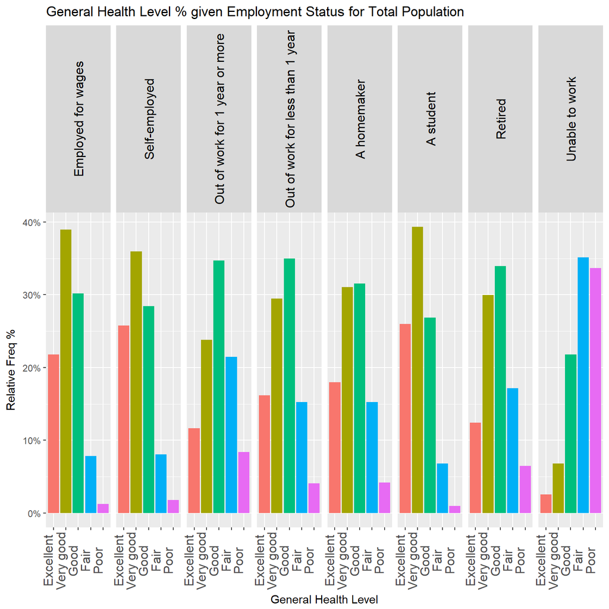

```r
#bar plot for relative frequency for probability of health level given employment status
ggplot(data=subset(brfss2013,!is.na(employ1)&!is.na(genhlth)),aes(x=genhlth,group=employ1)) + geom_bar(aes(y=..prop..,fill=factor(..x..)),stat="count") + labs(title="General Health Level % given Employment Status for Total Population",x="General Health Level",y="Relative Freq %") + theme(axis.text.x = element_text(angle=90,size=12,vjust=-0.1),strip.text.x = element_text(size = 12, colour = "black", angle = 90)) +facet_grid(~employ1) + scale_y_continuous(labels=scales::percent) +scale_fill_discrete(guide=FALSE)
```

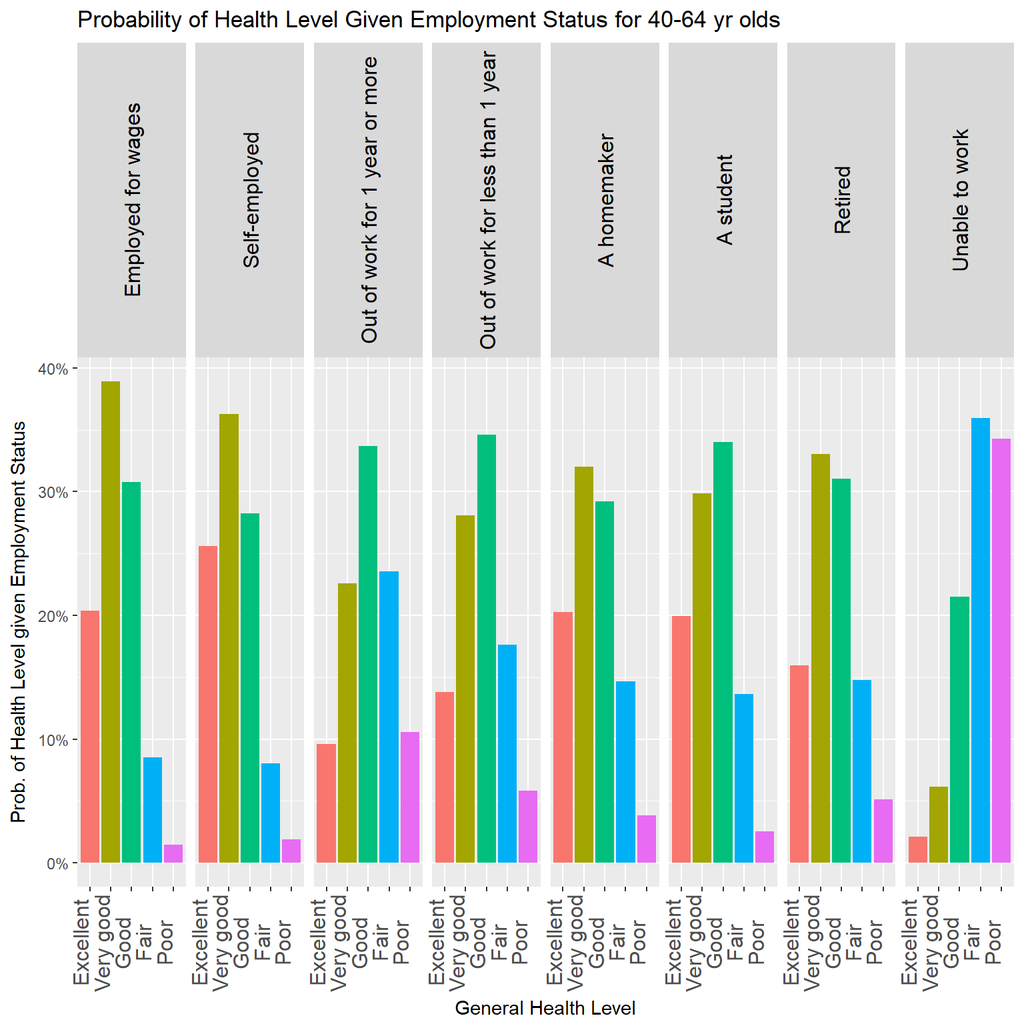

```r
#bar plot for relative frequency for probability of health level given employment status and 40-64 yr old
ggplot(data=subset(brfss_4064,!is.na(genhlth)&!is.na(employ1)), aes(x=genhlth,group=employ1)) +  geom_bar(aes(y=..prop..,fill =factor(..x..)),stat='count')+ scale_y_continuous(labels=scales::percent) + theme(axis.text.x = element_text(angle=90,size=12,vjust=-0.1),strip.text.x = element_text(size = 12, colour = "black", angle = 90)) + labs(title="Probability of Health Level Given Employment Status for 40-64 yr olds",x="General Health Level",y="Prob. of Health Level given Employment Status") + facet_grid(.~employ1) +scale_fill_discrete(guide=FALSE)
```

So we observe that given you are between 40-64 years old and retired, your probability of being in excellent health is 16%. This is lower than those who are Self-Employed(25%), Employed for Wages(20.4%), a Homemaker(20.2%) or a Student(19%). This is a bit unfortunate since I was hoping Americans would be able to retire in good health compared to their counterparts who continue working within the same age group. In fact, those that are retired have a slightly lower probability of being in excellent condition than the whole population of people between 40-64 year olds (16% vs 17%).

So from this are we able to asses that you have a lower chance of being in “Excellent” general health if you choose to retire early instead of working? Well we are unable to definitively make that judgement for the reasons below. Although there is an “Unable to Work” category, it likely does not account for people that don’t consider themselves “Unable to Work” but still choose not to work because of their health and as a result choose to retire early because of their financial security thereby lowering the total general health levels of retirees. Additionally as we can see in the frequency % barplot of the 40-64 year olds below, the largest 5 year group of individuals within the subset are 60-64 year olds. Since they are obviously older and have a higher chance of bad health, they bring the health level down for the whole 40-64 yr old group.

What we can say for sure though is that that Health Level and Employment Status are not independent variables.

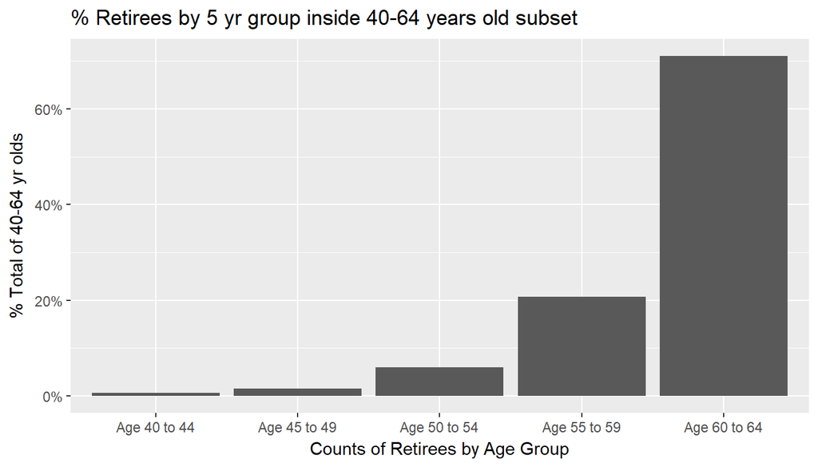

```r
#creating new dataset with only retirees between 40-64 years old
brfss_4064_ret <- brfss_4064[brfss_4064$employ1 %in% c("Retired"),]

brfss_4064_ret %>% group_by(X_ageg5yr) %>% summarise(n=n()) %>% mutate(freq=n/sum(n)) %>%
ggplot(aes(x=X_ageg5yr,y=freq)) + geom_bar(stat="identity")+ xlab("Counts of Retirees by Age Group") + ggtitle("% Retirees by 5 yr group inside 40-64 years old subset") +ylab("% Total of 40-64 yr olds") + scale_y_continuous(labels=scales::percent)
```

Considering all of this let us dig a little further and find out if given that someone is retired between the ages 40-64 years old, which 5 year group has the highest “Excellent” level of health. Or in other words which group of retirees has the highest probability of Excellent health level given they are between 40-64 years old? We should expect the youngest Age Group (40-44) but let us see.

```r
#relative freq table for general health level within 40 64 year old brackets
ptab_HealthRet_4064_ret <- round(prop.table(table(brfss_4064_ret$genhlth,brfss_4064_ret$X_ageg5yr),margin=2),3)
ptab_HealthRet_4064_ret <- ptab_HealthRet_4064_ret[,5:9]
ptab_HealthRet_4064_ret
```

```
##
##             Age 40 to 44 Age 45 to 49 Age 50 to 54 Age 55 to 59
##   Excellent        0.212        0.166        0.157        0.169
##   Very good        0.274        0.254        0.272        0.340
##   Good             0.274        0.269        0.314        0.288
##   Fair             0.185        0.203        0.180        0.147
##   Poor             0.055        0.109        0.076        0.057
##
##             Age 60 to 64
##   Excellent        0.156
##   Very good        0.335
##   Good             0.319
##   Fair             0.143
##   Poor             0.047
```

```r
#Calculates # of people who are retired and between the ages 40-44.
length(brfss_4064_ret[brfss_4064_ret$X_ageg5yr=="Age 40 to 44",])
```

```
## [1] 330
```

**Research Question 2**

Is an invdividuals Cigarettes smoking frequency independent or dependent on what month the survey was taken?

This question is of interest because although I expect the variables to be independent of each other, I am curious if things like new years resolutions could have decreased smoking habits in January or if the changing of the seasons could have done the same, or if some other event might have increased smoking.

```r
round(prop.table(table(brfss2013$smokday2)),3)
```

```
##
##  Every day  Some days Not at all
##      0.257      0.100      0.643
```

With above output from the total population, we observe that: 26% of people smoke everyday 10% smoke some days 64% do not smoke at all.

Let us also take a look at the distribution of when people were surveyed in the data set.

```r
#prob table for what month people were surveyed.
round(prop.table(table(brfss2013$imonth)),3)
```

```
##
##   January  February     March     April       May      June      July
##     0.070     0.087     0.090     0.087     0.082     0.077     0.089
##    August September   October  November  December
##     0.086     0.078     0.086     0.085     0.082
```

```r
#mean of average surveyed month
round(mean(prop.table(table(brfss2013$imonth))),3)
```

```
## [1] 0.083
```

We observe that on average 8.33% of the population were surveyed each month. With the lowest amount of people being surveyed in January (6.9%), June(7.7%), September(7.8%) with the highest being March(9.0%).

It is a bit unusual that less people were surveyed in January but that could be because the surveyors took vacations then or could not gather survey results for a variety of other reasons. In my opinion the count isnt too low enough to cause any anomalies.

Knowing that the 26% of population smokes everyday and 10% smoke on some days, we can compare it to the relative frequency given the month the inviduals were surveyed to see if they are similar.

```r
#contingency table for relative frequency of smoking habits given month surveyed.
ptab_SmokeMonth <- round(prop.table(table(brfss2013$imonth,brfss2013$smokday2),margin=1),3)
ptab_SmokeMonth
```

```
##
##             Every day Some days Not at all
##   January       0.264     0.103      0.633
##   February      0.258     0.098      0.643
##   March         0.267     0.101      0.632
##   April         0.257     0.101      0.642
##   May           0.261     0.101      0.638
##   June          0.251     0.102      0.647
##   July          0.253     0.101      0.646
##   August        0.259     0.099      0.642
##   September     0.261     0.100      0.639
##   October       0.246     0.100      0.654
##   November      0.252     0.097      0.651
##   December      0.252     0.098      0.649
```

```r
#(mean,SD) of relative frequency of smoking given user smokes [1]Every day, [2]Some Days, [3]Not at all
c(mean(ptab_SmokeMonth[,1])+sd(ptab_SmokeMonth[,1])*2,mean(ptab_SmokeMonth[,1])-sd(ptab_SmokeMonth[,1])*2)
```

```
## [1] 0.2689342 0.2445658
```

```r
c(mean(ptab_SmokeMonth[,2])+sd(ptab_SmokeMonth[,2])*2,mean(ptab_SmokeMonth[,2])-sd(ptab_SmokeMonth[,2])*2)
```

```
## [1] 0.10364661 0.09652005
```

```r
c(mean(ptab_SmokeMonth[,3])+sd(ptab_SmokeMonth[,3])*2,mean(ptab_SmokeMonth[,3])-sd(ptab_SmokeMonth[,3])*2)
```

```
## [1] 0.6566182 0.6293818
```

Below the contingency table are values that represent bounds that we can compare the invidual frequency %’s with. The bounds are defined as 2 standard deviations below the mean and above mean for the Every Day, Some Days and Not at all categories in that order.

The reason for doing this was to confirm that the relative frequencies are all close in value to each other and not out of the ordinary since they all fall within 2 S.Ds from the mean.

If we remember from intial summary statistics, smoking frequency % for the whole population was: Every day Some days Not at all 0.257 0.100 0.643 Since all our relative frequencies are really close to these values, I feel comfortable making the conclusion:

We can confirm independence between the variables Frequency of Smoking and which month the individual was surveyed: P(Smoke Every day | Surveyed in January) = P(Smoke Every day)

As an extra step, we will visualize this in the bar graph below.

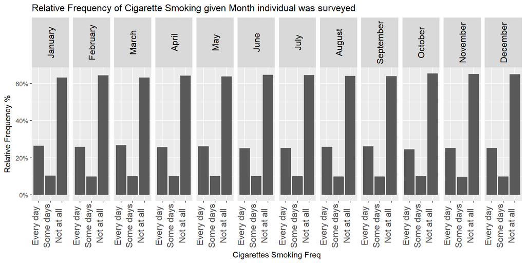

```r
#barplot of relative frequency of smoking
ggplot(data=subset(brfss2013,!is.na(imonth)&!is.na(smokday2)), aes(x=smokday2,group=imonth)) + geom_bar(aes(y= ..prop..)) + scale_y_continuous(labels=scales::percent)+facet_grid(.~imonth) + theme(axis.text.x = element_text(angle=90,size=12,vjust=-0.1),strip.text.x = element_text(size = 12, colour = "black", angle = 90)) + labs(title="Relative Frequency of Cigarette Smoking given Month individual was surveyed",x="Cigarettes Smoking Freq", y="Relative Frequency %")
```

If it wasn’t clear before with the contingency table, we can clearly see independence in the graph!

**Research quesion 3:**

Would the variable for # of children in households be a good indicator of an individuals general health level? Which households by # of children have the highest health levels?

We will clean the data bit in the code below.

```r
#converting variables to factors
brfss2013$X_chldcnt <- as.factor(brfss2013$X_chldcnt)
brfss2013$genhlth <- as.factor(brfss2013$genhlth)
brfss2013$sex <- as.factor(brfss2013$sex)
```

Our question involves 3 categorical variables: General Health Level (response, ordinal), Gender and # of Children in the Household (ordinal).

We will take a quick look at the frequency of these variables invidividually on the whole population before proceeding.

```r
#fequency % for General Health Level
prop.table(table(brfss2013$genhlth))
```

```
##
##  Excellent  Very good       Good       Fair       Poor
## 0.17452786 0.32478409 0.30738684 0.13623390 0.05706731
```

```r
#fequency % for Gender
prop.table(table(brfss2013$sex))
```

```
##
##      Male    Female
## 0.4093658 0.5906342
```

```r
#fequency % for # Children in the Household
prop.table(table(brfss2013$X_chldcnt))
```

```
##
##           No children in household             One child in household
##                        0.734375223                        0.108699782
##          Two children in household        Three children in household
##                        0.095365632                        0.040509096
##         Four children in household Five or more children in household
##                        0.014147233                        0.006903033
```

Now we will produce the frequency tables related to our question by first producing a relative frequency table for males, then females and finally a nice visual bar graph to compare.

The Relative Frequency Table for General Health Level given # of Children in Household and MALES:

```r
#creating relative frequency table for general health level for males given # of children in the household.
round(prop.table(table(brfss2013$genhlth[brfss2013$sex=="Male"],brfss2013$X_chldcnt[brfss2013$sex=="Male"]),margin=2),3)
```

```
##
##             No children in household One child in household
##   Excellent                    0.163                  0.209
##   Very good                    0.312                  0.349
##   Good                         0.320                  0.310
##   Fair                         0.143                  0.099
##   Poor                         0.062                  0.033
##
##             Two children in household Three children in household
##   Excellent                     0.229                       0.228
##   Very good                     0.378                       0.368
##   Good                          0.287                       0.296
##   Fair                          0.083                       0.084
##   Poor                          0.023                       0.024
##
##             Four children in household Five or more children in household
##   Excellent                      0.235                              0.230
##   Very good                      0.328                              0.332
##   Good                           0.313                              0.295
##   Fair                           0.091                              0.104
##   Poor                           0.033                              0.039
```

The Relative Frequency Table for General Health Level given # of Children in Household and FEMALES:

```r
round(prop.table(table(brfss2013$genhlth[brfss2013$sex=="Female"],brfss2013$X_chldcnt[brfss2013$sex=="Female"]),margin=2),3)
```

```
##
##             No children in household One child in household
##   Excellent                    0.155                  0.197
##   Very good                    0.318                  0.332
##   Good                         0.306                  0.301
##   Fair                         0.152                  0.125
##   Poor                         0.068                  0.046
##
##             Two children in household Three children in household
##   Excellent                     0.232                       0.232
##   Very good                     0.361                       0.339
##   Good                          0.279                       0.298
##   Fair                          0.098                       0.105
##   Poor                          0.030                       0.027
##
##             Four children in household Five or more children in household
##   Excellent                      0.234                              0.225
##   Very good                      0.325                              0.298
##   Good                           0.300                              0.304
##   Fair                           0.112                              0.136
##   Poor                           0.029                              0.037
```

Bar Graph for visualization:

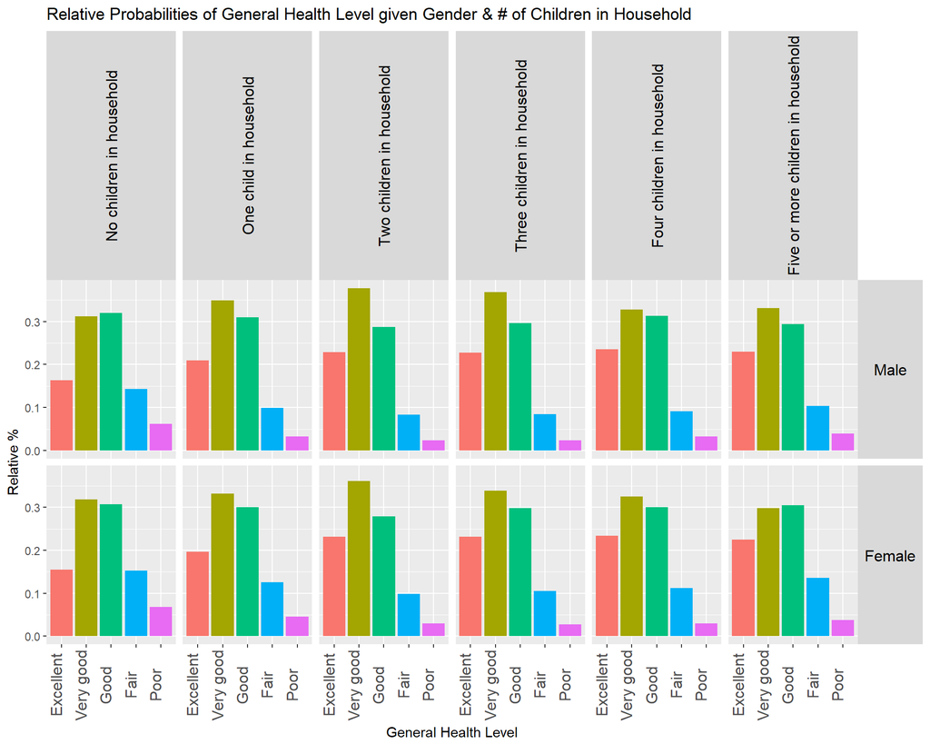

```r
#bar plot by relative frequency of health level, given gender and # of children in household
ggplot(data=subset(brfss2013,!is.na(sex)& !is.na(genhlth) & !is.na(X_chldcnt)),aes(x=genhlth,group=sex)) + geom_bar(aes(y=..prop..,fill=factor(..x..)))+ facet_grid(sex~X_chldcnt)+theme(axis.text.x = element_text(angle=90,size=12,vjust=0.),strip.text.x = element_text(size = 12, colour = "black", angle = 90),strip.text.y = element_text(size = 12, colour = "black", angle = 0))+labs(title="Relative Probabilities of General Health Level given Gender & # of Children in Household",y="Relative %",x="General Health Level")+scale_fill_discrete(guide=FALSE)
```

Also living in an atomic unit can possibly promote healthier lifestyles because of co-dependence and responsibilities in making the unit work. There is no such pressure on individuals who are not rearing a child since they do not have extra incentive to make sure they are well to take care of another.

Our summary statistic from earlier was as follows for frequency of health outcomes for the entire population: Excellent Very good Good Fair Poor 0.17452786 0.32478409 0.30738684 0.13623390 0.05706731